# matplotlib: Line Charts

Patrick Ho

2018-08-03

```python
%matplotlib inline
from matplotlib import pyplot as plt
```

### Line Chart

```python
values = [1, 2, 4, 8, 16, 32, 64, 128, 256]
x_locs = [i for i in range(len(values))]
```

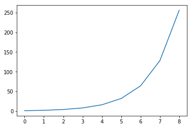

```python
plt.plot(x_locs, values);
```

### Multiple Lines

```python
values2 = list(reversed(values))
values3 = [x + y for x,y in zip(values, values2)]
```

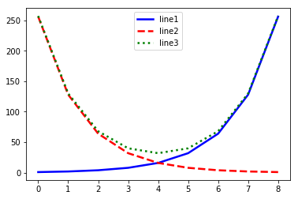

```python
plt.plot(x_locs, values,  color='blue' , label='line1', linewidth=2.5, linestyle='solid')
plt.plot(x_locs, values2, color='red'  , label='line2', linewidth=2.5, linestyle='dashed')
plt.plot(x_locs, values3, color='green', label='line3', linewidth=2.5, linestyle='dotted')

plt.legend();
```

# matplotlib: Bar Charts

Patrick Ho

2018-08-03

```python
%matplotlib inline
from collections import Counter
from matplotlib import pyplot as plt
```

### Bar Chart

```python
labels = ['a', 'b', 'c', 'd', 'e']
values = [1, 3, 2, 4, 3]

# Set x axis tick locations
x_locs = [i for i, _ in enumerate(labels)]
```

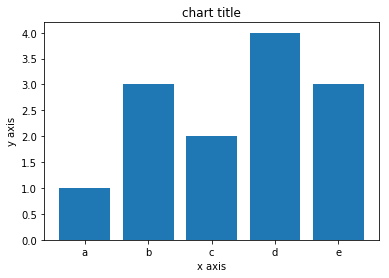

```python
plt.bar(x_locs, values)

plt.xlabel('x axis')
plt.ylabel('y axis')
plt.title('chart title')
plt.xticks(x_locs, labels);
```

#### With Error Bars

```python
errors = [0.2, 0.4, 0.2, 0.6, 0.5]  # +/- error
```

```
<BarContainer object of 5 artists>
```

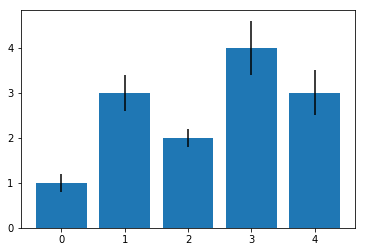

```python
plt.bar(x_locs, values, yerr=errors)
```

```python
errors2 = [[0.2, 0.4, 0.2, 0.6, 0.5],  # - error
           [0.5, 0.1, 0.1, 0.2, 0.2]]  # + error
```

```
<BarContainer object of 5 artists>
```

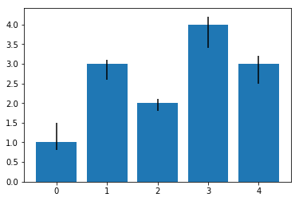

```python
plt.bar(x_locs, values, yerr=errors2)
```

### Histogram

```python
values2 = [43,54,48,29,62,76,38,46,62,54,59,35,55,43,32,48,50,54,36,35]

bins = 5
values_bin = Counter(x // bins * bins for x in values2)

x_locs = [x for x in values_bin.keys()]
```

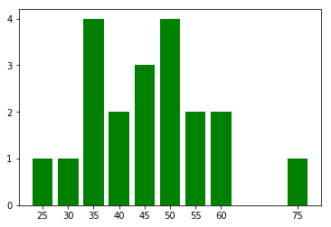

```python
plt.bar(x_locs, values_bin.values(), color='green', width=4)
plt.xticks(x_locs)
plt.yticks(range(0, max(values_bin.values()) + 1));
```

# pandas: Analysis

Patrick Ho

2018-08-03

```python
import pandas as pd
import numpy as np

pd.__version__
```

```python
df = pd.DataFrame({'A' : ['foo', 'bar', 'foo', 'bar', 'foo', 'bar', 'foo', 'foo'],
                   'B' : ['one', 'one', 'two', 'three', 'two', 'two', 'one', 'three'],
                   'C' : [1, 3, 5, 7, 9, 11, np.NaN, 15],
                   'D' : [2, 4, 6, 8, np.NaN, 12, 14, 16]})
```

### Inspect

```python
# Number of rows
len(df)
df.shape[0]

# Number of columns
df.shape[1]

# First/last few rows
df.head(10)
df.tail(10)

# Limit number of rows to show
pd.options.display.max_rows = 5
```

### Frequency Counts

```python
# Single variable
df['A'].value_counts()
```

```
foo    5
bar    3
Name: A, dtype: int64
```

```python
# Single variable, sorted by index name
df['A'].value_counts().sort_index()
```

```
bar    3
foo    5
Name: A, dtype: int64
```

```python
# Single variable, using groupby() instead
df.groupby('A').size()
```

```
A
bar    3
foo    5
dtype: int64
```

```python
# Single variable, with condition
df.groupby(df['A'] == 'foo').size()
```

```
A
False    3
True     5
dtype: int64
```

```python
# Single variable, across all columns
df.groupby('A').count()
```

| A | B | C | D |
| --- | --- | --- | --- |
| bar | 3 | 3 | 3 |
| foo | 5 | 4 | 4 |

```python
# Multiple variables
df.groupby(['A', 'B']).size()
```

```
A    B
bar  one      1
     three    1
     two      1
foo  one      2
     three    1
     two      2
dtype: int64
```

### Averages

```python
# Mean of all numeric variables, excludes missings
df.mean()
```

```
C    7.285714
D    8.857143
dtype: float64
```

```python
# Mean of all rows, excludes missings and non-numeric
df.mean(1)
```

```
0     1.5
1     3.5
2     5.5
3     7.5
4     9.0
5    11.5
6    14.0
7    15.5
dtype: float64
```

```python
# Single variable
df.groupby('A').mean()
```

| A | C | D |
| --- | --- | --- |
| bar | 7.0 | 8.0 |
| foo | 7.5 | 9.5 |

```python
# Multiple variables
df.groupby(['A', 'B']).mean()
```

| A | B | C | D |
| --- | --- | --- | --- |
| bar | one | 3.0 | 4.0 |
|  | three | 7.0 | 8.0 |
|  | two | 11.0 | 12.0 |
| foo | one | 1.0 | 8.0 |
|  | three | 15.0 | 16.0 |
|  | two | 7.0 | 6.0 |

### Apply Function

```python
# Cumulative sum
df.apply(np.cumsum)
```

|  | A | B | C | D |
| --- | --- | --- | --- | --- |
| 0 | foo | one | 1.0 | 2.0 |
| 1 | foobar | oneone | 4.0 | 6.0 |
| 2 | foobarfoo | oneonetwo | 9.0 | 12.0 |
| 3 | foobarfoobar | oneonetwothree | 16.0 | 20.0 |
| 4 | foobarfoobarfoo | oneonetwothreetwo | 25.0 | NaN |
| 5 | foobarfoobarfoobar | oneonetwothreetwotwo | 36.0 | 32.0 |
| 6 | foobarfoobarfoobarfoo | oneonetwothreetwotwoone | NaN | 46.0 |
| 7 | foobarfoobarfoobarfoofoo | oneonetwothreetwotwoonethree | 51.0 | 62.0 |

```python
# Normalise
df[['C', 'D']].apply(lambda x: (x - x.mean())/x.std())
```

|  | C | D |
| --- | --- | --- |
| 0 | -1.303930 | -1.300309 |
| 1 | -0.889043 | -0.921052 |
| 2 | -0.474156 | -0.541795 |
| 3 | -0.059270 | -0.162539 |
| 4 | 0.355617 | NaN |
| 5 | 0.770504 | 0.595975 |
| 6 | NaN | 0.975231 |
| 7 | 1.600278 | 1.354488 |

### Aggregation Function

```python
# Apply different functions to each variable - Pass in dictionary of functions
df.groupby('A').agg({'C': np.mean, 'D': np.size})
```

| A | C | D |
| --- | --- | --- |
| bar | 7.0 | 3.0 |
| foo | 7.5 | 5.0 |

```python
# Apply multiple functions to same variable
df.groupby(['A', 'B']).agg({'C': [np.size, np.mean]})
```

| A | B | C size | C mean |
| --- | --- | --- | --- |
| bar | one | 1.0 | 3.0 |
|  | three | 1.0 | 7.0 |
|  | two | 1.0 | 11.0 |
| foo | one | 2.0 | 1.0 |
|  | three | 1.0 | 15.0 |
|  | two | 2.0 | 7.0 |

# Resampling Permutation Test

Patrick Ho

2018-07-31

```python
import pandas as pd
import numpy as np
import matplotlib.pyplot as plt
```

### Create data

```python
a = [84, 57, 63, 99, 72, 46, 76, 91]
b = [81, 74, 56, 69, 66, 62, 69, 61, 87, 65, 44, 69]
group = ['a'] * len(a) + ['b'] * len(b)

df = pd.DataFrame({'group': group,
                   'value': a + b})

df.head(3)
```

|  | group | value |
| --- | --- | --- |
| 0 | a | 84 |
| 1 | a | 57 |
| 2 | a | 63 |

### Calculate means

Group A has a higher mean than Group B. Is this significant?

```python
a_mean = df[df['group']=='a']['value'].mean()
b_mean = df[df['group']=='b']['value'].mean()

print('Group A mean = %2.1f' % a_mean)
print('Group B mean = %2.1f' % b_mean)
print('Mean diff = %2.1f' % (a_mean - b_mean))
```

```
Group A mean = 73.5
Group B mean = 66.9
Mean diff = 6.6
```

### Permutation test

- If we assume null hypothesis, i.e. no difference between groups, then the observed values could have come from either group
- Build a distribution of possible mean differences under the null hypothesis by shuffling values between groups

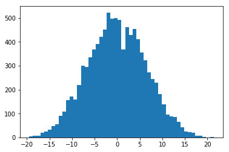

```python
np.random.seed(1)

num_sim = 10000
diff = []

for i in range(num_sim):
    df['group_shuf'] = np.random.permutation(group)
    a_mean = df[df['group_shuf']=='a']['value'].mean()
    b_mean = df[df['group_shuf']=='b']['value'].mean()
    diff.append(a_mean - b_mean)

plt.hist(diff, bins=50)
plt.show()
```

### Significance

- Using the distribution created we find that 15% of simulated mean differences are 6.6 or above
- So we do not reject null hypothesis at p<0.05

```python
p_val = sum(x >= 6.6 for x in diff) / len(diff)
print("p-value = %0.2f" % p_val)
```

```
p-value = 0.15
```

Reference:

- [Jake Vanderplas - Statistics for Hackers - PyCon 2016](https://www.youtube.com/watch?v=Iq9DzN6mvYA)

# Batch Gradient Descent

Patrick Ho

2018-07-31

```python
%matplotlib inline
import numpy as np
import matplotlib.pyplot as plt
from mpl_toolkits.mplot3d import Axes3D
from matplotlib import cm
```

### Batch Gradient Descent

Cost Function for Linear Regression: $$J(\theta)=\frac{1}{2m}\sum_{i=1}^m(h_\theta(x^{(i)})-y^{(i)})^2$$

where the hypothesis $h_\theta(x)$ is: $$h_\theta(x)=\theta^Tx=\theta_0+\theta_1x_1+\theta_2x_2...$$

```python
def computeCost(X, y, theta):
    """ Compute cost for linear regression

    Compute cost of using theta as the parameter for linear regression
    to fit the data points in X and y
    """

    m = len(y)
    J = 1/(2*m) * sum((X.dot(theta) - y) ** 2)

    return J
```

Simultaneously update $\theta_j$ for all $j$: $$\theta_j:=\theta_j-\alpha\frac{1}{m}\sum_{i=1}^m(h_\theta(x^{(i)})-y^{(i)})x_j^{(i)}$$

```python
def gradientDescent(X, y, theta, alpha, num_iters):
    """ Performs batch gradient descent to learn theta

    Updates theta by taking num_iters gradient steps with
    learning rate alpha
    """

    m = len(y)
    J_history = np.zeros((num_iters, 1))

    for i in range(num_iters):

        # Perform a single gradient step on the parameter vector theta
        theta = theta - (alpha/m) * (X.dot(theta) - y).T.dot(X).T

        # Save the cost J in every iteration
        J_history[i] = computeCost(X, y, theta)

    return theta, J_history
```

### Linear Regression - Single Variable

#### Load Data

```
Text(0.5,0,'Population of City in 10,000s')
```

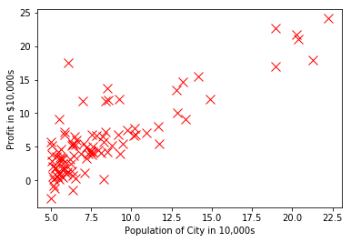

```python
# Load data
data = np.loadtxt('data/ex1data1.csv', delimiter=',')

# Split into target and feature, use reshape to make 2D
m = len(data)
X = data[:, 0].reshape(m, 1)
y = data[:, 1].reshape(m, 1)

# Plot data
plt.plot(X, y, 'rx', markersize=10)
plt.ylabel('Profit in $10,000s')
plt.xlabel('Population of City in 10,000s')
```

#### Fit Model Using Gradient Descent

```python
# Add column of ones to X to accommodate intercept term
o = np.ones(m).reshape(m, 1)
X = np.concatenate((o, X), axis=1)

# Initialise fitting parameters to 0
theta = np.zeros((2, 1))

# Run gradient descent with learning rate 0.01 over 1500 iterations
theta, J_history = gradientDescent(X, y, theta, alpha=0.01, num_iters=1500)

# Output results
print('theta_0 Intercept  = %0.3f' % theta[0])
print('theta_1 Population = %0.3f' % theta[1])
```

```
theta_0 Intercept  = -3.630
theta_1 Population = 1.166
```

#### Visualize Model

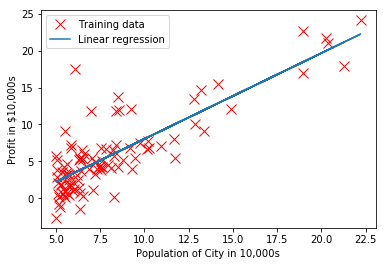

```python
plt.plot(X[:, 1], y, 'rx', markersize=10, label='Training data')
plt.plot(X[:, 1], np.dot(X, theta), '-', label='Linear regression')

plt.ylabel('Profit in $10,000s')
plt.xlabel('Population of City in 10,000s')
plt.legend()
```

#### Visualize Cost $J(\theta)$

```python
# Grid over which we will calculate J
theta0_vals = np.arange(-10, 10, 0.5)
theta1_vals = np.arange(-1, 4, 0.1)

# Initialize J_vals to a matrix of 0's
J_vals = np.zeros((len(theta0_vals), len(theta1_vals)))

# Fill out J_vals
for i in range(len(theta0_vals)):
    for j in range(len(theta1_vals)):
        t = np.array([theta0_vals[i], theta1_vals[j]]).reshape(2,1)
        J_vals[i, j] = computeCost(X, y, t)

# Create meshgrid
theta0_vals, theta1_vals = np.meshgrid(theta0_vals, theta1_vals)
```

##### Surface Plot

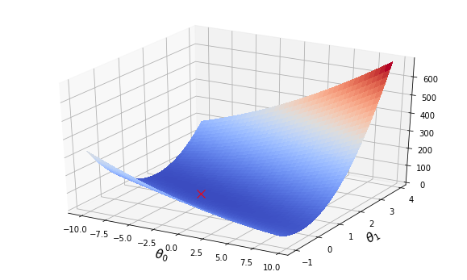

```python
fig = plt.figure(figsize=(10,6))
ax = fig.gca(projection='3d')

ax.plot_surface(theta0_vals, theta1_vals, J_vals.T,
                       cmap=cm.coolwarm,
                       linewidth=0, antialiased=False)
plt.plot(theta[0], theta[1], 'rx', markersize=10, linewidth=2)

plt.xlabel(r'$\theta_0$', fontsize=15)
plt.ylabel(r'$\theta_1$', fontsize=15)
```

##### Contour Plot

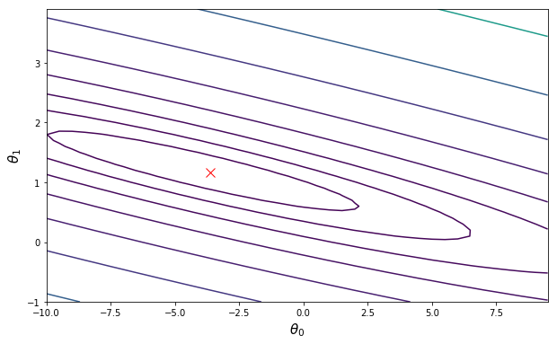

```python
fig = plt.figure(figsize=(10,6))
ax = fig.gca()

ax.contour(theta0_vals, theta1_vals, J_vals.T, np.logspace(-2, 3, 20))
plt.plot(theta[0], theta[1], 'rx', markersize=10, linewidth=2)

plt.xlabel(r'$\theta_0$', fontsize=15)
plt.ylabel(r'$\theta_1$', fontsize=15)
```

### Linear Regression - Multiple Variables

#### Load Data

```python
# Load data
data = np.loadtxt('data/ex1data2.csv', delimiter=',')

# Split into target and feature, use reshape to make 2D
m = len(data)
X = data[:, [0,1]].reshape(m, 2)
y = data[:, 2].reshape(m, 1)

# Print top 5 rows - Square Feet, Num Bedrooms
X[:5, :]
```

```
array([[  2.10400000e+03,   3.00000000e+00],
       [  1.60000000e+03,   3.00000000e+00],
       [  2.40000000e+03,   3.00000000e+00],
       [  1.41600000e+03,   2.00000000e+00],
       [  3.00000000e+03,   4.00000000e+00]])
```

#### Normalize Features

- Scales each feature so they have mean of 0 and std dev of 1
- Helps gradient descent converge quicker

##### Define Function

```python
def featureNormalize(X):
    """ Normalizes the features in X

    Returns a normalized version of X where the mean value of
    each feature is 0 and the standard deviation is 1
    """

    mu = np.mean(X, axis=0)
    sigma = np.std(X, axis=0)

    X_norm = (X - mu) / sigma

    return X_norm, mu, sigma
```

##### Apply Feature Normalization

```python
print('Before normalization:')
print('Square Feet:  mean = %0.2f, std dev = %0.2f' % (X[:, 0].mean(), X[:, 0].std()))
print('Num Bedrooms: mean = %0.2f, std dev = %0.2f' % (X[:, 1].mean(), X[:, 1].std()))

X, mu, sigma = featureNormalize(X)

print('\nAfter normalization:')
print('Square Feet:  mean = %0.2f, std dev = %0.2f' % (X[:, 0].mean(), X[:, 0].std()))
print('Num Bedrooms: mean = %0.2f, std dev = %0.2f' % (X[:, 1].mean(), X[:, 1].std()))
```

```
Before normalization:
Square Feet:  mean = 2000.68, std dev = 786.20
Num Bedrooms: mean = 3.17, std dev = 0.75

After normalization:
Square Feet:  mean = 0.00, std dev = 1.00
Num Bedrooms: mean = 0.00, std dev = 1.00
```

#### Fit Model Using Gradient Descent

```python
# Add column of ones to X to accommodate intercept term
o = np.ones(m).reshape(m, 1)
X = np.concatenate((o, X), axis=1)

# Initialise fitting parameters to 0
theta = np.zeros((3, 1))

# Run gradient descent with learning rate 0.1 over 1000 iterations
theta, J_history = gradientDescent(X, y, theta, alpha=0.1, num_iters=1000)

# Output results
print('theta_0 Intercept    = %0.3f' % theta[0])
print('theta_1 Square Feet  = %0.3f' % theta[1])
print('theta_2 Num Bedrooms = %0.3f' % theta[2])
```

```
theta_0 Intercept    = 340412.660
theta_1 Square Feet  = 109447.796
theta_2 Num Bedrooms = -6578.355
```

#### Predict

What is the price of a house with 1650 square feet and 3 bedrooms?

```python
test = np.append([1], [(np.array([1650, 3])-mu)/sigma])
pred = np.dot(test, theta)

print('Prediction = $%0.2f' % pred)
```

```
Prediction = $293081.46
```

#### Fit Using Normal Equations

Not necessary to normalize features $$\theta=(X^TX)^{-1}X^Ty$$

```python
theta_norm = np.linalg.pinv(X.T.dot(X)).dot(X.T).dot(y)
```

#### Predict

What is the price of a house with 1650 square feet and 3 bedrooms?

```python
pred_norm = np.dot(test, theta_norm)

print('Prediction = $%0.2f' % pred_norm)
```

```
Prediction = $293081.46
```

References:

- https://www.coursera.org/learn/machine-learning/home/welcome

# Git

Patrick Ho

2018-07-30

## Git Setup

1. Install using apt-get
   - `sudo apt-get update`
   - `sudo apt-get install git`
2. Verify successful installation – If successful, this will print out the git version number
   - `git --version`
3. Configure username and email – These details will be used to identify who ‘committed’ the changes.
   - `git config --global user.name "<your name>"`
   - `git config --global user.email "<email address>"`
4. Configure default text editor – This is used to edit your commit messages
   - `git config --global core.editor "<text editor>"`

## Git Areas

Working --- Staging --- Local --- Remote

- **Working Directory:** The files you’re editing
- **Staging Area:** Where you assign which files you want to commit into the repository
- **Local Repo:** The repository on your own machine
- **Remote Repo:** The repository in the cloud or network (e.g. GitHub), often named as "origin"

## Creating Repositories

#### `git init`

Create a git repository in the current directory.

TIP: You can check by seeing if there’s a hidden ".git" directory created.

#### `git clone <remove repo URL>`

Create a git repository in the current directory that is a copy of the remote repo with full history of changes.

Use `--depth=1` if you only want to get the latest version without all the history.

#### GitHub: Fork

Creates a copy of a GitHub repo and registers it under your username.

If you then clone this new repo locally, the original repo is referred to as *upstream*.  
Local --- Remote (origin) --- Remote (upstream)

## Making Changes

#### `git add <files>`

Add file(s) to staging area so they are ready to be committed.

If you want to un-stage a file, use `git reset <file>`.

TIP: Use a *.gitignore* file to ignore tracking specified files/folders.

#### `git commit -m "<message>"`

Commit staged changes into the local repo ("add a dot to the chain").

Every commit should have a properly written message, there are two options:

- Use the `-m` flag to write the message on command line
- If you have `core.editor` defined, you can omit the `-m` flag and it will load up the text editor

#### `git status`

Lists files in staging area that will be committed, AND  
Lists changed files in working directory have not been staged

TIP: Always use this before committing to check you are committing exactly what you intended

#### `git diff`

Compare differences between working directory and staging area:  
Working <-diff-> Staging --- Local --- Remote

If file is in staging area, there will be no diff as work and staging are the same.

#### `git diff --staged`

Compare differences between staging area and repository:  
Working --- Staging <-diff-> Local --- Remote

View the actual code/text changes that you are about to commit.

#### Reading Diff Output

[figure not shown]

#### HEAD

This is a reference to the last commit in the currently checked out branch (i.e. the tip).

If you checkout a specific commit instead of a branch, you will be in a ‘detached HEAD’ state. Any new commits while in this state won’t be reachable by any branch – you won’t see the commit in your git log.

TIP: If you need to make changes to old versions, create a branch: `git checkout -b <branch> <commit>`

TIP: If you need to find "unreachable" commits, you can use `git reflog`

#### Remote Branch

Read-only bookmarks pointing to where the branch was in the remote repo the last time Git checked.

- They take the form: `<remote>/<branch>`
- They are automatically updated when your local repo is in contact with the remote repo.

Use `git branch -r` to list out the remote branches that the local repo is currently aware of.

[figure not shown]

## Inspecting Change History

#### `git log`

Show the commit history.

- Use `--stat` to show additional information about the committed changes
- Use `--oneline` to condense each commit to a single line

TIP: Good commit messages == Better looking and more useful commit history!

#### `git log --graph --oneline <branch1> <branch2> <etc>`

Show the history of commits reachable by the specified branches in a graphical format

[figure not shown]

#### `git diff <base commit ID> <compare commit ID>`

Compare differences between two commits (typically the base commit is older) - The two commits don’t have to be adjacent - You can use shortened commit IDs

#### `git checkout <commit ID>`

View files as at a particular point in history.

This moves you "back in time", so you won’t see later commits in the log. To get back to the latest version of the branch:  
`git checkout <branch, e.g. master>`

## Syncing Repositories

#### `git remote`

View remote repositories.  
Use `-v` for verbose listing.

#### `git remote add <name of remote, e.g. origin> <address, e.g. GitHub repo>`

Create a remote connection.

#### `git push <remote> <branch>`

Push (upload) commits on the branch to the remote repository.

#### `git pull <remote> <branch>`

Pull (download) commits on the branch from the remote repository.

Equivalent to a `git fetch` followed by a `git merge`.

#### `git fetch <remote> <branch>`

Download commits from the specified branch on the remote repo to your local repo. The resulting commits will appear on a remote branch.

This allows you to see what’s been done on the remote repo without impacting your own work. If you’re happy to integrate these changes to your local repo, you would then merge it in yourself (`git pull` = `git fetch` + `git merge`).

TIP: It’s generally safer to use `git fetch` rather than go straight to `git pull`, as it gives you the option to review the changes first

## Branching

Think of branches as a **pointer or a label** to a specific commit, rather than a container of commits. As commits are created, they track along and point to the new commits.

#### `git branch`

List branches.

The * indicates which branch is currently checked out, the one that will update with changes.

#### `git checkout <branch>`

Switch to the specified branch.

#### `git branch <new branch name>`

Create a new branch.

Does not immediately checkout the new branch. Create and checkout in one command with:  
`git checkout -b <new branch name>`

#### `git merge <branch>`

Merge specified branch into currently checked out branch.

E.g. When merging *new-feature* branch into *master*:

- Only the *master* branch moves because that's checked out
- The *new-feature* branch stays where it is

[figure not shown]

#### Resolving merge conflicts

Sometimes Git isn’t sure how to complete the merge, e.g. if there are changes to the same line of code.

1. Use `git status` to identify which files need resolving.
2. The attempted merge will be in your working directory. Fix up the file manually then `git add/commit` as usual.

#### Merging and Rebasing

While working on your branch, the *master* branch may move on from where you branched from. There are two options to bring your branch up to date:

- `git merge`: Merge master into your branch. Non-destructive.
- `git rebase`: Moves entire branch to tip of master and creates new commits. Cleaner history.

[figure not shown]

## Good Practices

#### Atomic Commits

After your initial commit of the project, you should only commit atomic changes going forward.

Atomic changes are small and only encompass one irreducible task (e.g. feature, fix, or improvement). Just large enough to be a completed block of work so the code base is never broken.

Benefits include:

- Easier code reviews, as all changes in the commit are for a single task
- Easier code merging
- Easier roll back, so if there’s a bug you can exclude one change at a time

TIP: If you make multiple changes at once on different files, you can use the staging process to divide it into multiple commits

#### Commit Message Format

**Subject line – Required, first line of the message**

- Limit to 50 characters
- Use proper capitalisation
- Do not end with a period
- Use the imperative mood, like you’re giving a command (e.g. "Fix" rather than "Fixed")
  - Think of it like this: "Applying this commit will <subject line>"

**Body text – Optional**

- Separate from subject line with a blank line
- Wrap text at 72 characters
- Explain what and why, rather than how

TIP: Use #<number> in message to link to a GitHub Issue

#### Release Management

In GitHub, you should create a release on a branch (usually master) when there is a version of the code that’s ready to be distributed for use. This helps ensure people use the right versions of the project.

Use semantic versioning (http://semver.org/) for the release version numbering. The release tag should look like: `v<major>.<minor>.<patch>` (e.g. v1.15.3)

- Use the 'v' prefix – Makes it clear that it’s a version number
- Increment Major for: Large rebuilds, Changes that break backwards compatibility
- Increment Minor for: New features
- Increment Patch for: Bug fixes

# pandas: Columns

Patrick Ho

2018-07-29

```python
import pandas as pd
import numpy as np

pd.__version__
```

```
'0.23.1'
```

### Add/Drop

```python
# Add column to dataframe
df['col'] = pd.Series(['A', 'B', 'C'])

# Drop columns by index
df.drop(df.columns[[1, 2]], axis=1)

# Drop columns by name
df.drop(['B', 'C'], axis=1)
```

### Missing Values

```python
df = pd.DataFrame({'col1': ['a', np.NaN, 'c', 'd'],
                   'col2': [1, 2, np.NaN, 4]})
```

```python
# Which values are missing?
df.isnull()
```

|  | col1 | col2 |
| --- | --- | --- |
| 0 | False | False |
| 1 | True | False |
| 2 | False | True |
| 3 | False | False |

```python
# How many missing values in each column?
df.isnull().sum()
```

```
col1    1
col2    1
dtype: int64
```

```python
# How many missing values in total?
df.isnull().sum().sum()
```

```
2
```

```python
# Select rows with missing values
df[df['col1'].isnull()]
```

|  | col1 | col2 |
| --- | --- | --- |
| 1 | NaN | 2.0 |

```python
# Exclude row if value is missing
df[df['col1'].notnull()]
```

|  | col1 | col2 |
| --- | --- | --- |
| 0 | a | 1.0 |
| 2 | c | NaN |
| 3 | d | 4.0 |

#### Fill In Missing

```python
# Fill with blank
df['col1'] = df['col1'].fillna('')
df
```

|  | col1 | col2 |
| --- | --- | --- |
| 0 | a | 1.0 |
| 1 |  | 2.0 |
| 2 | c | NaN |
| 3 | d | 4.0 |

```python
# Backward fill - last non-N/A value upward
df['col1'] = df['col1'].fillna(method='bfill')
df
```

|  | col1 | col2 |
| --- | --- | --- |
| 0 | a | 1.0 |
| 1 | c | 2.0 |
| 2 | c | NaN |
| 3 | d | 4.0 |

```python
# Forward fill - first non-N/A value downward
df['col1'] = df['col1'].fillna(method='ffill')
df
```

|  | col1 | col2 |
| --- | --- | --- |
| 0 | a | 1.0 |
| 1 | a | 2.0 |
| 2 | c | NaN |
| 3 | d | 4.0 |

### Numeric Data

Columns are Series, can apply math on them

```python
df = pd.DataFrame({'baz': [1, 3, 5, 7],
                   'zoo': [2, 4, 6, 8]})
```

```python
df['baz'] + 10
```

```
0    11
1    13
2    15
3    17
Name: baz, dtype: int64
```

```python
df['zoo'] > 5
```

```
0    False
1    False
2     True
3     True
Name: zoo, dtype: bool
```

### String Data

Apply string functions to a Series using 'str' namespace

```python
df = pd.DataFrame({'foo': ['one', 'one', 'two', 'two'],
                   'bar': ['A', 'B', 'A', 'B']})
```

```python
# Flag elements which start with a particular substring
df['foo'].str.startswith('on')
```

```
0     True
1     True
2    False
3    False
Name: foo, dtype: bool
```

```python
# Find elements that match regex, return NaN for non-matches
df['foo'].str.extract('(w)')
```

|  | 0 |
| --- | --- |
| 0 | NaN |
| 1 | NaN |
| 2 | w |
| 3 | w |

```python
# Replace values based on a condition
df.loc[df['foo']=='one', 'bar'] = 'C'
df
```

|  | foo | bar |
| --- | --- | --- |
| 0 | one | C |
| 1 | one | C |
| 2 | two | A |
| 3 | two | B |

### Date/Time Data

Apply date/time functions to a Series using 'dt' namespace

```python
# Get month numbers
df['datevar'].dt.month
```

# pandas: Dataframes

Patrick Ho

2018-07-28

```python
import pandas as pd
import numpy as np

pd.__version__
```

```
'0.23.1'
```

### Create

```python
# Create empty dataframe
df = pd.DataFrame()

# Create from CSV
df = pd.read_csv('./data/file.csv')

# Create from random values
df = pd.DataFrame(np.random.randn(5, 3),
                  columns=['col1', 'col2', 'col3'])

# Create from dictionary
df = pd.DataFrame({'col1': ['A', 'B', 'C'],
                   'col2': [1, 2, 3]})

# Create from Series
col1 = pd.Series(['A', 'B', 'C'])
col2 = pd.Series([1, 2, 3])

df = pd.concat([col1, col2], axis=1)
df.columns = ['col1', 'col2']
```

### Index

```python
df = pd.DataFrame({'col1': [3, 1, 2],
                   'col2': ['A', 'B', 'C'],
                   'col3': [8, 5, 7],
                   'col4': [True, False, True]})
df
```

|  | col1 | col2 | col3 | col4 |
| --- | --- | --- | --- | --- |
| 0 | 3 | A | 8 | True |
| 1 | 1 | B | 5 | False |
| 2 | 2 | C | 7 | True |

```python
# Set index - move columns 'left' to become an index
df = df.set_index(['col1', 'col3'])  # can have multiple indexes
df
```

| col1 | col3 | col2 | col4 |
| --- | --- | --- | --- |
| 3 | 8 | A | True |
| 1 | 5 | B | False |
| 2 | 7 | C | True |

```python
# Reset index - move columns back to the 'right'
df = df.reset_index('col1')
df
```

| col3 | col1 | col2 | col4 |
| --- | --- | --- | --- |
| 8 | 3 | A | True |
| 5 | 1 | B | False |
| 7 | 2 | C | True |

### Subset

#### Select Columns

```python
# Using column name
df['col 1!']          # if column name has spaces or special characters
df[['col1', 'col2']]  # multiple columns

# Using dot notation
df.col1

# Using loc function
df.loc[:, ['col1','col2']]
```

#### Select Rows

##### By column value

Must use bitwise operators '&' (AND) and '|' (OR)

```python
# Select rows on condition
df[df['col'] == 5]
df[(df['col'] > 5) & (df['col'] < 10)]

# Select rows with nulls in specified column
df[df['col'].isnull()]

# Select rows without nulls in specified column
df[df['col'].notnull()]
```

##### By index label

Selecting rows by index is faster than '=='. Even faster if already sorted by index.

```python
df.loc[0]          # row with index label 0
df.loc[1:3]        # rows with index label 1 to 3 inclusive
df.loc['A']        # rows with index label 'A'
df.loc[['A','B']]  # rows with index label 'A' or 'B'
df.loc['A', 15]    # rows where first index is 'A' and second index is 15
```

##### By position

```python
df.iloc[0]         # first row
df.iloc[1:5]       # rows at position 1 to 4
```

#### Select Columns and Rows

```python
# col1 and col2, rows where col3<4
df[['col1','col2']][df['col3']<4]

# col1 and col2, rows with index label 'A' or 'B'
df[['col1','col2']].loc[['A', 'B']]

# col1 and col2, rows at position 1 to 3
df[['col1','col2']].iloc[1:4]
```

### Sort

```python
# Sort by value ascending
df.sort_values(by='col1')

# Sort by value descending
df.sort_values(by='col1', ascending=False)
```

```python
# Sort by index
df = pd.DataFrame({'col1': [3, 1, 2],
                   'col2': [1, 2, 3]}).set_index('col1')
df.sort_index()
```

| col1 | col2 |
| --- | --- |
| 1 | 2 |
| 2 | 3 |
| 3 | 1 |

### Append

```python
# Keep duplicate rows
pd.concat([df1, df2])

# Drop duplicate rows
pd.concat([df1, df2]).drop_duplicates()

# Drop duplicate rows based on specified columns, keeping first occurrence
pd.concat([df1, df2]).drop_duplicates(subset=['col1', 'col2'])

# Drop duplicate rows based on specified columns, keeping last occurrence
pd.concat([df1, df2]).drop_duplicates(subset=['col1', 'col2'], keep='last')
```

### Join

```python
# Column to column inner join
pd.merge(df1, df2,
         left_on='coll', right_on='colr',
         how='inner',
         suffixes=['', '_r'])  # column name suffixes for duplicates

# Index to index left join
pd.merge(df1, df2,
         left_index=True, right_index=True,
         how='left',
         suffixes=['', '_r'])

# Column to index outer join
pd.merge(df1, df2,
         left_on='coll', right_index=True,
         how='outer',
         suffixes=['', '_r'])
```

### Reshape

#### Pivoting

```python
df = pd.DataFrame({'foo': ['one', 'one', 'one', 'two', 'two', 'two'],
                   'bar': ['A', 'B', 'C', 'A', 'B', 'C'],
                   'baz': [1, 2, 3, 4, 5, 6],
                   'zoo': ['x', 'z', 'x', 'x', 'z', 'z']})
df
```

|  | foo | bar | baz | zoo |
| --- | --- | --- | --- | --- |
| 0 | one | A | 1 | x |
| 1 | one | B | 2 | z |
| 2 | one | C | 3 | x |
| 3 | two | A | 4 | x |
| 4 | two | B | 5 | z |
| 5 | two | C | 6 | z |

```python
# Pivot - Transpose tall to wide
df.pivot(index='foo', columns='bar', values='baz')
```

| bar foo | A | B | C |
| --- | --- | --- | --- |
| one | 1 | 2 | 3 |
| two | 4 | 5 | 6 |

```python
# Pivot - Transpose tall to wide with aggregation of values
df.pivot_table(index='foo', columns='zoo', values='baz', aggfunc=np.sum)
```

| zoo foo | x | z |
| --- | --- | --- |
| one | 4 | 2 |
| two | 4 | 11 |

#### Stacking/Unstacking

Dataframes require both left and top index. If you stack/unstack too much, it will become a Series.

```python
df = pd.DataFrame({'foo': ['one', 'one', 'two', 'two'],
                   'bar': ['A', 'B', 'A', 'B'],
                   'baz': [1, 3, 5, 7],
                   'zoo': [2, 4, 6, 8]}).set_index(['foo', 'bar'])
df
```

| foo | bar | baz | zoo |
| --- | --- | --- | --- |
| one | A | 1 | 2 |
|  | B | 3 | 4 |
| two | A | 5 | 6 |
|  | B | 7 | 8 |

```python
# Move innermost left index 'up' to innermost top index - Wider
df_unstacked = df.unstack()
df_unstacked
```

| bar foo | baz A | baz B | zoo A | zoo B |
| --- | --- | --- | --- | --- |
| one | 1 | 3 | 2 | 4 |
| two | 5 | 7 | 6 | 8 |

```python
# Move innermost top index 'down' to innermost left index - Taller
df_unstacked.stack()
```

| foo | bar | baz | zoo |
| --- | --- | --- | --- |
| one | A | 1 | 2 |
|  | B | 3 | 4 |
| two | A | 5 | 6 |
|  | B | 7 | 8 |

# Python: Dictionaries

Patrick Ho

2018-07-27

### Create

```python
# Init empty dictionary
empty_dict = {}

# Init dictionary with key:value pairs
a_dict = {'Alice':30, 'Bob':35, 'Chris':28, 'Dave':'N/A'}

# Init dictionary using dict()
a_dict = dict(Alice=30, Bob=35, Chris=28, Dave='N/A')
```

### Inspect

```python
# Number of key-value pairs in dictionary
len(a_dict)

# Check if key is in dictionary
'a' in a_dict
any(x in a_dict for x in ['a', 'b'])  # check if any items in dictionary
all(x in a_dict for x in ['a', 'b'])  # check if all items in dictionary

# Check if value is in dictionary
'a' in a_dict.values()

# List of keys
a_dict.keys()

# List of values
a_dict.values()

# List of key-value pairs (as tuples)
a_dict.items()
```

### Access

```python
# Lookup single value by key
a_dict['Bob']
a_dict.get('Frank')               # returns None
a_dict.get('Frank', 'Not Found')  # returns 'Not Found'
```

### Add items to the dictionary

```python
# Add new item
a_dict['Ed'] = 49
```

### Edit items in the dictionary

```python
# Edit existing item
a_dict['Dave'] = 42

# Assignment creates reference, not a copy!
a_dict = {'a':1, 'b':2, 'c':3}
b_dict = a_dict
a_dict['a'] = 99  # both values for 'a' and 'b' will be 99
```

### Remove items from the dictionary

```python
# Delete item
del a_dict['Alice']

# Remove all items leaving empty dictionary
a_dict.clear()

# Delete dictionary
del a_dict
```

### Sort

Dictionaries have no order, can either:

- Create a sorted representation as a list
- Use OrderedDict

```python
import operator
import collections

# Sorted by value, represent as a list of tuples
a_dict = {'a':3, 'b':5, 'c':2, 'd':8}
a_dict_sorted = sorted(a_dict.items(), key=operator.itemgetter(1))

# Store as OrderedDict
a_dict_ordered = collections.OrderedDict(a_dict_sorted)
```

### Combine

```python
# Add a dictionaries key-value pairs to another with dupes removed
a_dict.update(dict2)
```

# Python: Error Handling

Patrick Ho

2018-07-27

### Error Handling

- List of error types: https://docs.python.org/3/library/exceptions.html

```python
try:
    numerator = int(input('Enter numerator: '))
    denominator = int(input('Enter denominator: '))
    result = numerator/denominator
    print(result)
except ValueError:
    print('No value entered')
except ZeroDivisionError:
    print('Divide by zero')
except Exception as e:
    print('Other error: ', e)
```

```
Enter numerator: 1
Enter denominator: 0
Divide by zero
```

- Newer posts
- Older posts